# Stabilité d’un système solaire à trois corps

Emmanuel Doumard

14 septembre 2017

## Introduction

Le but de cet article est d’étudier la stabilité à long terme d’un système solaire à trois corps. On définit comme système solaire à trois corps un système de trois corps physiques de grande masse soumis à la seule gravité de ses composants (les autres interactions physiques étant négligeables). Par système solaire, on entend que l’un des trois corps a une masse très importante comparée aux deux autres.

Pendant toute l’étude, on prendra pour sujet d’étude notre propre système solaire auquel on a laissé uniquement le Soleil, Jupiter et Saturne. Ces deux planètes ayant eues un impact considérable lors de la formation de notre système solaire, il est intéressant de se demander si leur influence gravitationnelle l’une sur l’autre est suffisante pour que le système composée du Soleil et de ses deux planètes ne soit pas stable à long terme.

Pour simplifier le problème, on le suppose plan : on suppose que Jupiter et Saturne gravitent dans des orbites parfaitement circulaires (avant considération des interactions gravitationnelles entre l’une et l’autre) et parfaitement dans le plan de d’écliptique (le plan équatorial solaire). Ce n’est pas exactement le cas mais ces approximations sont raisonnables dans le cas de notre étude.

Par “stable”, on entend que, sur plusieurs millions/milliars d’années, Saturne et/ou Jupiter pourraient quitter le système solaire ou tomber sur le Soleil.

## Implémentation et étude naïve

On commence par mettre en place le système. Dans la réalité, le Soleil se trouve au centre du système solaire, on le place donc dans son propre référenciel (héliocentrique), en (0,0). Par rapport à lui se trouve Jupiter, à 5 Unités Atronomiques (UA), 5 fois plus loin du Soleil que la terre. Pour la simplicité, on raisonnera en distance avec cette unité dans toute l’étude.

Nous allons donc faire varier la distance au Soleil de Saturne, pour voir à partir de quelle proximité à Jupiter son influence gravitationnelle est susceptible de perturber le système.

Pour calculer la position des 3 corps au cours du temps, le problème à trois corps étant démontré non résolvable mathématiquement, on fera une simulation grâce à la méthode de Runge-Kutta avec dérivée d’ordre 4 avec le language Python. Je vous invite à consulter https://fr.wikipedia.org/wiki/M%C3%A9thodes_de_Runge-Kutta#La_m.C3.A9thode_de_Runge-Kutta_d.27ordre_quatre_avec_d.C3.A9riv.C3.A9e_seconde pour plus de détails.

```python
def rungekutta(vitA, vitB, vitC, posA, posB, posC, masseA, masseB, masseC, pas, n): #vitA, vitB, posA, posB des tableaux,  [0] pour x,  [1] pour y
    XA=posA[0][0]
    XB=posB[0][0]
    YA=posA[0][1]
    YB=posB[0][1]
    XC=posC[0][0]
    YC=posC[0][1]
    x_bary=[(masseA*XA + masseB*XB + masseC*XC)/(masseA+masseB+masseC)]
    y_bary=[(masseA*YA + masseB*YB + masseC*YC)/(masseA+masseB+masseC)]
    XAtot=[]
    YAtot=[]
    XBtot=[]
    YBtot=[]
    XCtot=[]
    YCtot=[]
    EB=[]
    EC=[]
    rapportaxes=[]

    T=[] #Tableau des temps
    for i in xrange(0, n):

        k1xA=f(masseB, masseC, XA, YA, XB, YB, XC, YC) #k1=f(y_n)
        k2xA=f(masseB, masseC, XA + (pas/2)*vitA[0], YA, XB, YB, XC, YC) #k2=f(y_n + (pas/2)*y'_n)
        k3xA=f(masseB, masseC, XA + (pas/2)*vitA[0] + (pas**2/4)*k1xA, YA, XB, YB, XC, YC) #k3=f(y_n + (pas/2)*y'_n + (pas**2/4)*k1)
        k4xA=f(masseB, masseC, XA + pas*vitA[0] + (pas**2/2)*k2xA, YA, XB, YB, XC, YC) #k4=f(y_n + pas*y'_n + (pas**2/2)*k2)

        XA = XA + pas*vitA[0] + (pas**2/6)*(k1xA + k2xA + k3xA)

        vitA[0]+=(pas/6)*(k1xA + (2*k2xA) + (2*k3xA) + k4xA)

        k1yA=f(masseB, masseC, YA, XA, YB, XB, YC, XC)
        k2yA=f(masseB, masseC, YA + (pas/2)*vitA[1], XA, YB, XB, YC, XC)
        k3yA=f(masseB, masseC, YA + (pas/2)*vitA[1] + (pas**2/4)*k1yA, XA, YB, XB, YC, XC)
        k4yA=f(masseB, masseC, YA + pas*vitA[1] + (pas**2/2)*k2yA, XA, YB, XB, YC, XC)

        YA = YA + pas*vitA[1] + (pas**2/6)*(k1yA + k2yA + k3yA)

        vitA[1]+=(pas/6)*(k1yA + (2*k2yA) + (2*k3yA) + k4yA)

        k1xB=f(masseA, masseC, XB, YB, XA, YA, XC, YC)
        k2xB=f(masseA, masseC, XB + (pas/2)*vitB[0], YB, XA, YA, XC, YC)
        k3xB=f(masseA, masseC, XB + (pas/2)*vitB[0] + (pas**2/4)*k1xB, YB, XA, YA, XC, YC)
        k4xB=f(masseA, masseC, XB + pas*vitB[0] + (pas**2/2)*k2xB, YB, XA, YA, XC, YC)

        XB = XB + pas*vitB[0] + (pas**2/6)*(k1xB + k2xB + k3xB)

        vitB[0]+=(pas/6)*(k1xB + (2*k2xB) + (2*k3xB) + k4xB)

        k1yB=f(masseA, masseC, YB, XB, YA, XA, YC, XC)
        k2yB=f(masseA, masseC, YB + (pas/2)*vitB[1], XB, YA, XA, YC, XC)
        k3yB=f(masseA, masseC, YB + (pas/2)*vitB[1] + (pas**2/4)*k1yB, XB, YA, XA, YC, XC)
        k4yB=f(masseA, masseC, YB + pas*vitB[1] + (pas**2/2)*k2yB, XB, YA, XA, YC, XC)

        YB = YB + pas*vitB[1] + (pas**2/6)*(k1yB + k2yB + k3yB)

        vitB[1]+=(pas/6)*(k1yB + (2*k2yB) + (2*k3yB) + k4yB)

        k1xC=f(masseA, masseB, XC, YC, XA, YA, XB, YB)
        k2xC=f(masseA, masseB, XC + (pas/2)*vitC[0], YC, XA, YA, XB, YB)
        k3xC=f(masseA, masseB, XC + (pas/2)*vitC[0] + (pas**2/4)*k1xC, YC, XA, YA, XB, YB)
        k4xC=f(masseA, masseB, XC + pas*vitC[0] + (pas**2/2)*k2xC, YC, XA, YA, XB, YB)

        XC = XC + pas*vitC[0] + (pas**2/6)*(k1xC + k2xC + k3xC)

        vitC[0]+=(pas/6)*(k1xC + (2*k2xC) + (2*k3xC) + k4xC)

        k1yC=f(masseA, masseB, YC, XC, YA, XA, YB, XB)
        k2yC=f(masseA, masseB, YC + (pas/2)*vitC[1], XC, YA, XA, YB, XB)
        k3yC=f(masseA, masseB, YC + (pas/2)*vitC[1] + (pas**2/4)*k1yC, XC, YA, XA, YB, XB)
        k4yC=f(masseA, masseB, YC + pas*vitC[1] + (pas**2/2)*k2yC, XC, YA, XA, YB, XB)

        YC = YC + pas*vitC[1] + (pas**2/6)*(k1yC + k2yC + k3yC)

        vitC[1]+=(pas/6)*(k1yC + (2*k2yC) + (2*k3yC) + k4yC)

        if i%100==0:                     #On ne prend au final que une valeur sur 100 ou 1000
            XAtot.append(XA)
            XBtot.append(XB)
            XCtot.append(XC)
            YAtot.append(YA)
            YBtot.append(YB)
            YCtot.append(YC)
            x_bary.append((masseA*XA + masseB*XB + masseC*XC)/(masseA+masseB+masseC))
            y_bary.append((masseA*YA + masseB*YB + masseC*YC)/(masseA+masseB+masseC))

            #Calcul de l'excentricite
            X_B=XB-XA
            Y_B=YB-YA
            VX_B=vitB[0]-vitA[0]
            VY_B=vitB[1]-vitA[1]
            X_C=XC-XA
            Y_C=YC-YA
            VX_C=vitC[0]-vitA[0]
            VY_C=vitC[1]-vitA[1]

            h2_B=(X_B*VY_B-Y_B*VX_B)**2
            h2_C=(X_C*VY_C-Y_C*VX_C)**2

            rB=math.sqrt(X_B**2+Y_B**2)
            rC=math.sqrt(X_C**2+Y_C**2)

            v2B=VX_B**2+VY_B**2
            v2C=VX_C**2+VY_C**2
            energyB=0.5*v2B-G*(masseA+masseB)/rB
            energyC=0.5*v2C-G*(masseA+masseC)/rC

            axeB=-0.5*((2*math.pi)**2)*(masseA+masseB)/energyB
            axeC=-0.5*((2*math.pi)**2)*(masseA+masseC)/energyC

            facB=1-h2_B/(((2*math.pi)**2)*(masseA+masseB)*axeB)
            facC=1-h2_C/(((2*math.pi)**2)*(masseA+masseB)*axeC)

            e_B=math.sqrt(facB)
            e_C=math.sqrt(facC)
            EB.append(e_B)
            EC.append(e_C)

            rapportaxes.append(axeC/axeB)

            T.append(i*pas)
    return XAtot,XBtot,YAtot,YBtot,XCtot,YCtot,x_bary,y_bary,EB,EC,rapportaxes,T
```

On pars d’une position à Jupiter à 5UA et Saturne à 7UA. Après avoir laissé le système évoluer 4000 ans, on observe la trajectoire des planètes autour du soleil :

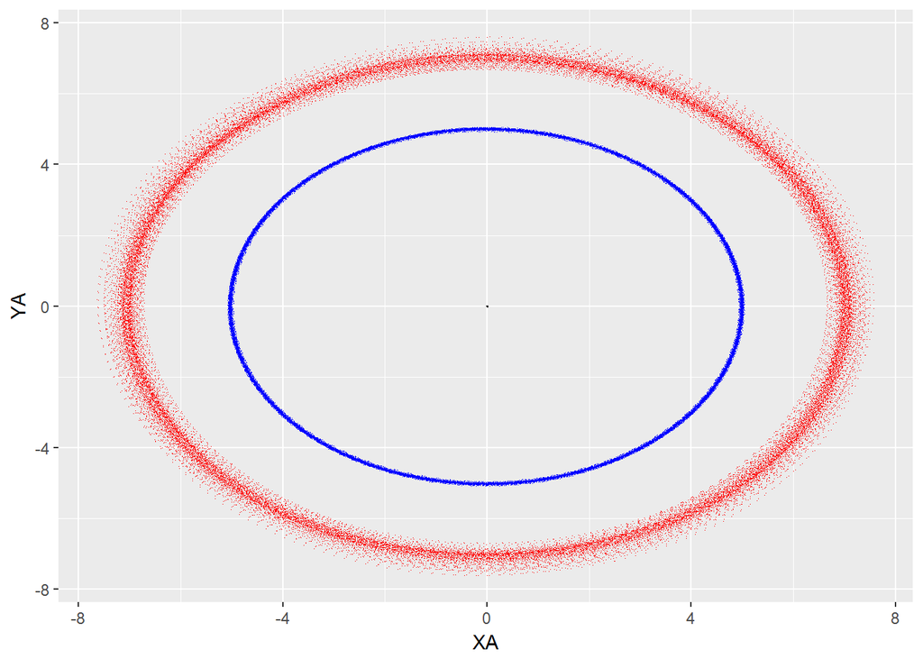

```r
mydata <- read.table("C:/Nadim/MRI/results.csv", sep="\t",header=T)
mydataOrb=mydata[,c("XA","YA","XB","YB","XC","YC")]
plot<-ggplot()+geom_point(data=mydataOrb,aes(x=XA,y=YA),size=0.001,stroke=0,shape=4)
plot<-plot+geom_point(data=mydataOrb,aes(x=XB,y=YB),color="blue",size=0.001,stroke=0,shape=4)
plot<-plot+geom_point(data=mydataOrb,aes(x=XC,y=YC),color="red",size=0.001,stroke=0,shape=4)
plot
```

On remarque que l’étude est difficile à réaliser avec ces données : on n’a pas la notion de temps, ni un critère objectif de stabilité. On raisonne alors par rapport à deux critères : l’excentricité des orbites de Jupiter et Saturne, et le rapport des demi-grands axes de leurs orbites.

L’excentricité d’une orbite permet de donner un critère d’évolution qui varie entre 0 (trajectoire parfaitement circulaire) et 1 (ellipse allongée en droite). On estime que lorsqu’elle dépasse 0.4, la planète a une trajectoire trop irrégulière et finira par sortir de la portée d’attraction du Soleil.

Le rapport des demi-grands axes est supposé rester plus ou moins constant (ou au moins périodiques) durant toute la durée de vie des planètes. Une variation importante et brusque dans ce rapport indiquerait une perte de la stabilité.

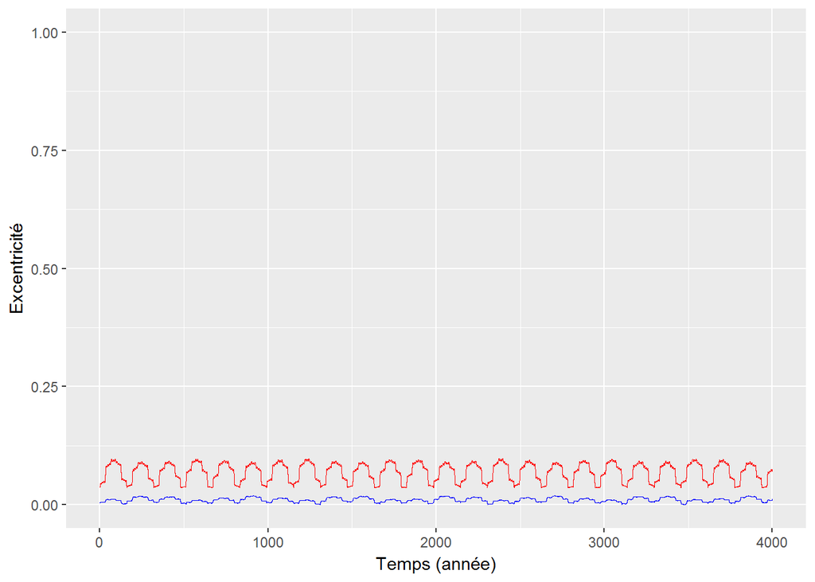

```r
mydata <- read.table("C:/Nadim/MRI/results6,5.csv", sep="\t",header=T)
mydataExc=mydata[,c("t","ExcB","ExcC")]
Exc <- ggplot()+geom_line(data=mydataExc,aes(x=t,y=ExcB),color="blue",size=0.01)+geom_line(data=mydataExc,aes(x=t,y=ExcC),color="red",size=0.01)+ylim(0,1)
Exc <- Exc + xlab("Temps (année)") + ylab("Excentricité")
Exc
```

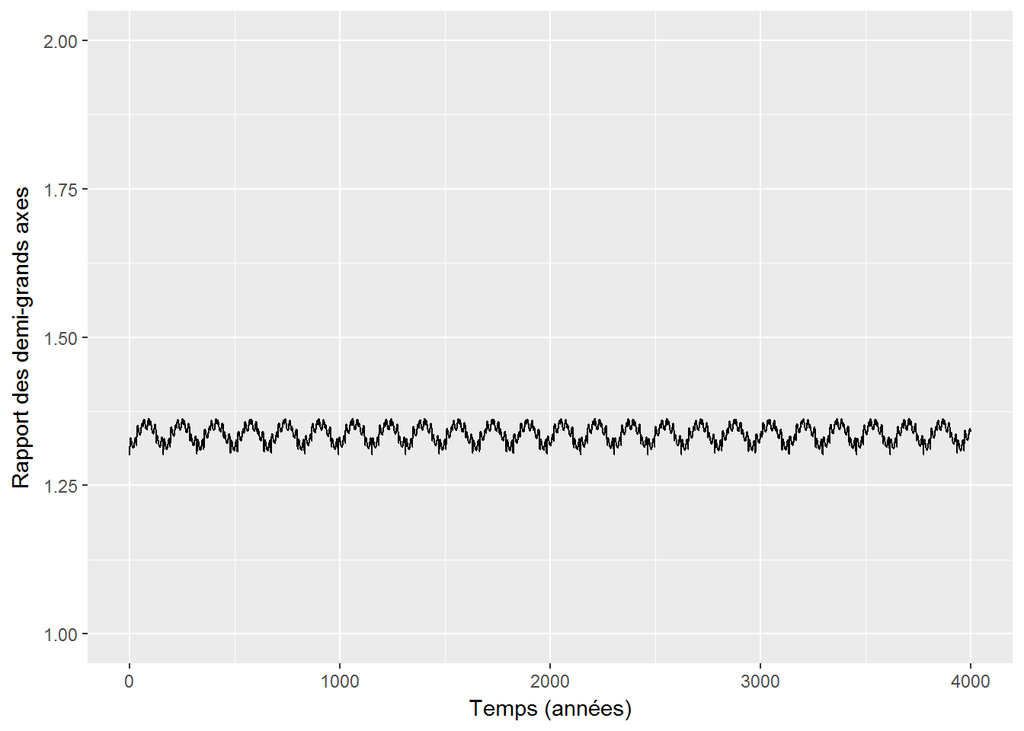

```r
mydataAxes=mydata[,c("t","rapport_axes")]
ggplot()+geom_line(data=mydataAxes,aes(x=t,y=rapport_axes))+xlab("Temps (années)")+ylab("Rapport des demi-grands axes")+ylim(1,2)
```